# Assignment 1 + 2

Keana Flores, Lindsey Mayer, Andrew Mikula

10/31/2021

*Research Question*

Did the adoption of an accessory dwelling unit (ADU) ordinance lower the cost of rent in Monroe County, Indiana?

*Prior Research*

Crane (2020) found that ADUs “have increased the supply of relatively low-cost rental units in low-density neighborhoods” in California, but it is either illegal or undesirable for many homeowners to do so, thus limiting the potential for a significant price effect. Ramsey-Musolf (2018) is also skeptical of the ability of California’s ADUs to provide large-scale low-income housing, finding that, among the 759 ADUs constructed in California in the available dataset, “no units were identified as available low-income housing.”

*Data + Definition of Sample Population*

The sample population for this study is Monroe County, Indiana between 2005 and 2019. The analysis will include the following variables:

INCOME: total family income (IPUMS) UNITS: # of units in structure (IPUMS) RENT: monthly rent (IPUMS) RACE: race (IPUMS) YEAR: pre 2009, post 2009 (IPUMS)

*References*

Rebecca Elisabeth Crane. 2020. “Is Granny in that Flat?: How Regulations Shape the Construction and Use of Accessory Dwelling Units in Los Angeles.” The California Digital Library. https://escholarship.org/uc/item/2wh204vz

Mike Hanks. April 4, 2019. “Bloomington opens door to more affordable housing units.” Adams Publishing Group. https://www.hometownsource.com/sun_current/community/bloomington/bloomington-opens-door-to-more-affordable-housing-units/article_f17b8092-5652-11e9-8951-47a5d871ac49.html

Darrel Ramsey-Musolf. Accessory Dwelling Units as Low-Income Housing: California’s Faustian Bargain. Urban Sci. 2(3), 89. DOI: https://doi.org/10.3390/urbansci2030089

Steven Ruggles, Sarah Flood, Sophia Foster, Ronald Goeken, Jose Pacas, Megan Schouweiler and Matthew Sobek. IPUMS USA: Version 11.0 [dataset]. Minneapolis, MN: IPUMS, 2021.

*Data*

```r
library(tidycensus)
library(tidyverse)
library(readxl)
library(knitr)
library(survey)
library(srvyr)
library(dplyr)
```

```r
library(ipumsr)
```

```r
ddi <- read_ipums_ddi("usa_00005.xml")
data <- read_ipums_micro(ddi) %>%
  filter(RENT > 0) %>%
    mutate(RACE = as_factor(RACE))
```

```
## Use of data from IPUMS USA is subject to conditions including that users should
## cite the data appropriately. Use command `ipums_conditions()` for more details.
```

```r
group_by(data, YEAR)
```

```
## # A tibble: 5,331 x 17
## # Groups:   YEAR [15]
##     YEAR        SAMPLE SERIAL CBSERIAL  HHWT   CLUSTER STATEICP COUNTYICP STRATA
##    <int>     <int+lbl>  <dbl>    <dbl> <dbl>     <dbl> <int+lb> <int+lbl>  <dbl>
##  1  2005 200501 [2005~ 415455     8046    49   2.01e12 22 [Ind~   1050 [] 290018
##  2  2005 200501 [2005~ 415676    16844   161   2.01e12 22 [Ind~   1050 [] 290018
##  3  2005 200501 [2005~ 415842    23905   278   2.01e12 22 [Ind~   1050 [] 290018
##  4  2005 200501 [2005~ 415842    23905   278   2.01e12 22 [Ind~   1050 [] 290018
##  5  2005 200501 [2005~ 415842    23905   278   2.01e12 22 [Ind~   1050 [] 290018
##  6  2005 200501 [2005~ 415842    23905   278   2.01e12 22 [Ind~   1050 [] 290018
##  7  2005 200501 [2005~ 415989    30105   137   2.01e12 22 [Ind~   1050 [] 290018
##  8  2005 200501 [2005~ 415989    30105   137   2.01e12 22 [Ind~   1050 [] 290018
##  9  2005 200501 [2005~ 415989    30105   137   2.01e12 22 [Ind~   1050 [] 290018
## 10  2005 200501 [2005~ 415989    30105   137   2.01e12 22 [Ind~   1050 [] 290018
## # ... with 5,321 more rows, and 8 more variables: GQ <int+lbl>, RENT <int+lbl>,
## #   UNITSSTR <int+lbl>, PERNUM <dbl>, PERWT <dbl>, RACE <fct>, RACED <int+lbl>,
## #   FTOTINC <dbl+lbl>
```

```r
group_data <- group_by(data, YEAR)
```

```r
svy_data <- data %>%
  as_survey_design(ids = CLUSTER,
                   strata = STRATA,
                   weights = HHWT)
```

```r
income_mean <- svy_data %>%
  summarize(mean = survey_mean(FTOTINC, vartype = c("ci", "var"), na.rm = TRUE))

rent_mean <- svy_data %>%
  summarize(mean = survey_mean(RENT, vartype = c("ci", "var"), na.rm = TRUE))

units_mean <- svy_data %>%
  summarize(mean = survey_mean(UNITSSTR, vartype = c("ci", "var"), na.rm = TRUE))
```

```r
income_quants <- svy_data %>%
  summarise(quants = survey_quantile(as.numeric(as.factor(FTOTINC)),
                                     quantiles =  c(0.25, 0.5, 0.75),
                                     vartype = NULL,
                                     na.rm = TRUE))

rent_quants <- svy_data %>%
  summarise(quants = survey_quantile(as.numeric(as.factor(RENT)),
                                     quantiles =  c(0.25, 0.5, 0.75),
                                     vartype = NULL))

units_quants <- svy_data %>%
  summarise(quants = survey_quantile(as.numeric(as.factor(UNITSSTR)),
                                     quantiles =  c(0.25, 0.5, 0.75),
                                     vartype = NULL))
```

```r
mean_summary <- rbind(income_mean, rent_mean, units_mean) %>%
    mutate(variable = c("Median Family Income",
                      "Monthly Average Rent",
                      "Units in Structure"))

quant_summary <- rbind(income_quants, rent_quants, units_quants) %>%
    mutate(variable = c("Median Family Income",
                      "Monthly Average Rent",
                      "Units in Structure"))

summary <- left_join(mean_summary, quant_summary) %>%
  mutate(sd = mean_var^0.5) %>%
  mutate(IQR = quants_q75 - quants_q25) %>%
  rename(median = quants_q50) %>%
  select(variable, mean, mean_low, mean_upp, median, sd, IQR)
kable(summary, digits=2)
```

| variable | mean | mean_low | mean_upp | median | sd | IQR |
| --- | --- | --- | --- | --- | --- | --- |
| Median Family Income | 34913.78 | 24585.03 | 45242.53 | 276 | 5267.50 | 383 |
| Monthly Average Rent | 848.96 | 817.86 | 880.06 | 71 | 15.86 | 45 |
| Units in Structure | 5.85 | 5.71 | 5.99 | 5 | 0.07 | 5 |

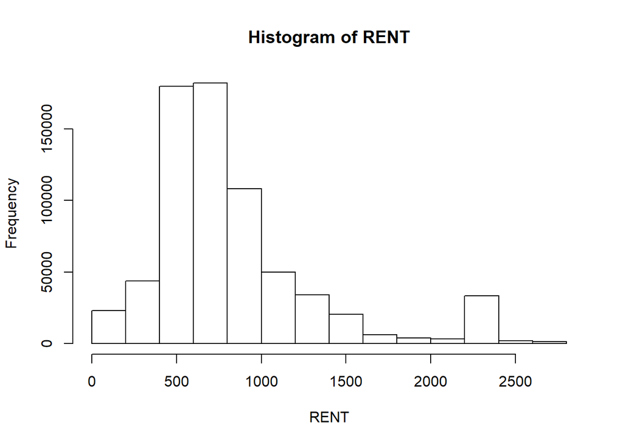

```r
rent_mean_hist <- svyhist(~RENT, design = svy_data,
                            freq = TRUE)
```

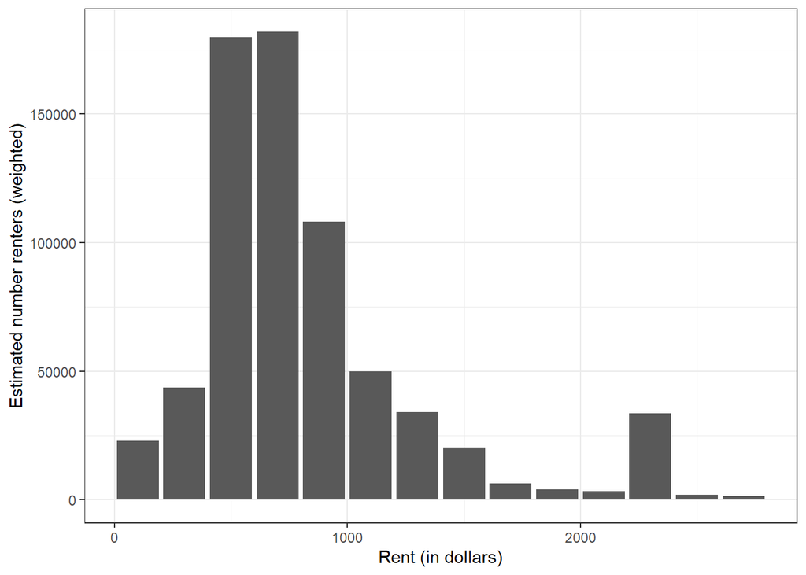

```r
rent_mean_hist_df <- tibble(mids = rent_mean_hist$mids,
                              counts = rent_mean_hist$counts)

ggplot(rent_mean_hist_df) +
  geom_bar(aes(x = mids, y = counts),
           stat = "identity") +
  theme_bw() +
  scale_x_continuous(name = "Rent (in dollars)") +
  scale_y_continuous(name = "Estimated number renters (weighted)")
```

```r
ed_shares <- svy_data %>%
  group_by(RACE) %>%
  summarize(share = survey_prop(vartype = "ci"))

kable(ed_shares)
```

| RACE | share | share_low | share_upp |
| --- | --- | --- | --- |
| White | 0.8151991 | 0.7969629 | 0.8334352 |
| Black/African American/Negro | 0.0507832 | 0.0392132 | 0.0623532 |
| American Indian or Alaska Native | 0.0034569 | 0.0013548 | 0.0055590 |
| Chinese | 0.0354600 | 0.0267238 | 0.0441961 |
| Japanese | 0.0060127 | 0.0020941 | 0.0099313 |
| Other Asian or Pacific Islander | 0.0486454 | 0.0388321 | 0.0584587 |
| Other race, nec | 0.0083689 | 0.0043512 | 0.0123865 |
| Two major races | 0.0303484 | 0.0234094 | 0.0372874 |
| Three or more major races | 0.0017256 | 0.0007631 | 0.0026880 |